# Risk Factor Analysis

## Outcome Variable

**Outcome Variable:** pers_wasted624

## Predictor Variables

**Intervention Variable:** ever_stunted06

**Adjustment Set:**

- sex
- arm
- brthmon
- vagbrth
- single
- W_mage
- W_mhtcm
- W_mwtkg
- W_mbmi
- W_meducyrs
- W_feducyrs
- W_parity
- delta_brthmon
- delta_vagbrth
- delta_single
- delta_W_mage
- delta_W_mhtcm
- delta_W_mwtkg
- delta_W_mbmi
- delta_W_meducyrs
- delta_W_feducyrs
- delta_W_parity

## Stratifying Variables

The analysis was stratified on these variable(s):

- studyid
- country

## Data Summary

| studyid | country | ever_stunted06 | pers_wasted624 | n_cell | n | outcome_variable |
| --- | --- | --- | --- | --- | --- | --- |
| ki0047075b-MAL-ED | BANGLADESH | 0 | 0 | 145 | 240 | pers_wasted624 |
| ki0047075b-MAL-ED | BANGLADESH | 0 | 1 | 10 | 240 | pers_wasted624 |
| ki0047075b-MAL-ED | BANGLADESH | 1 | 0 | 78 | 240 | pers_wasted624 |
| ki0047075b-MAL-ED | BANGLADESH | 1 | 1 | 7 | 240 | pers_wasted624 |
| ki0047075b-MAL-ED | BRAZIL | 0 | 0 | 160 | 207 | pers_wasted624 |
| ki0047075b-MAL-ED | BRAZIL | 0 | 1 | 2 | 207 | pers_wasted624 |
| ki0047075b-MAL-ED | BRAZIL | 1 | 0 | 45 | 207 | pers_wasted624 |
| ki0047075b-MAL-ED | BRAZIL | 1 | 1 | 0 | 207 | pers_wasted624 |
| ki0047075b-MAL-ED | INDIA | 0 | 0 | 135 | 235 | pers_wasted624 |
| ki0047075b-MAL-ED | INDIA | 0 | 1 | 14 | 235 | pers_wasted624 |
| ki0047075b-MAL-ED | INDIA | 1 | 0 | 72 | 235 | pers_wasted624 |
| ki0047075b-MAL-ED | INDIA | 1 | 1 | 14 | 235 | pers_wasted624 |
| ki0047075b-MAL-ED | NEPAL | 0 | 0 | 191 | 235 | pers_wasted624 |
| ki0047075b-MAL-ED | NEPAL | 0 | 1 | 1 | 235 | pers_wasted624 |
| ki0047075b-MAL-ED | NEPAL | 1 | 0 | 42 | 235 | pers_wasted624 |
| ki0047075b-MAL-ED | NEPAL | 1 | 1 | 1 | 235 | pers_wasted624 |
| ki0047075b-MAL-ED | PERU | 0 | 0 | 147 | 270 | pers_wasted624 |
| ki0047075b-MAL-ED | PERU | 0 | 1 | 0 | 270 | pers_wasted624 |
| ki0047075b-MAL-ED | PERU | 1 | 0 | 120 | 270 | pers_wasted624 |
| ki0047075b-MAL-ED | PERU | 1 | 1 | 3 | 270 | pers_wasted624 |
| ki0047075b-MAL-ED | SOUTH AFRICA | 0 | 0 | 152 | 259 | pers_wasted624 |
| ki0047075b-MAL-ED | SOUTH AFRICA | 0 | 1 | 2 | 259 | pers_wasted624 |
| ki0047075b-MAL-ED | SOUTH AFRICA | 1 | 0 | 105 | 259 | pers_wasted624 |
| ki0047075b-MAL-ED | SOUTH AFRICA | 1 | 1 | 0 | 259 | pers_wasted624 |
| ki0047075b-MAL-ED | TANZANIA, UNITED REPUBLIC OF | 0 | 0 | 140 | 245 | pers_wasted624 |
| ki0047075b-MAL-ED | TANZANIA, UNITED REPUBLIC OF | 0 | 1 | 0 | 245 | pers_wasted624 |
| ki0047075b-MAL-ED | TANZANIA, UNITED REPUBLIC OF | 1 | 0 | 105 | 245 | pers_wasted624 |
| ki0047075b-MAL-ED | TANZANIA, UNITED REPUBLIC OF | 1 | 1 | 0 | 245 | pers_wasted624 |
| ki1000108-CMC-V-BCS-2002 | INDIA | 0 | 0 | 167 | 370 | pers_wasted624 |
| ki1000108-CMC-V-BCS-2002 | INDIA | 0 | 1 | 11 | 370 | pers_wasted624 |

[output cut: 90 more lines]

The following strata were considered:

- studyid: ki0047075b-MAL-ED, country: BANGLADESH
- studyid: ki0047075b-MAL-ED, country: BRAZIL
- studyid: ki0047075b-MAL-ED, country: INDIA
- studyid: ki0047075b-MAL-ED, country: NEPAL
- studyid: ki0047075b-MAL-ED, country: PERU
- studyid: ki0047075b-MAL-ED, country: SOUTH AFRICA
- studyid: ki0047075b-MAL-ED, country: TANZANIA, UNITED REPUBLIC OF
- studyid: ki1000108-CMC-V-BCS-2002, country: INDIA
- studyid: ki1000108-IRC, country: INDIA
- studyid: ki1000109-EE, country: PAKISTAN
- studyid: ki1000109-ResPak, country: PAKISTAN
- studyid: ki1000304b-SAS-CompFeed, country: INDIA
- studyid: ki1000304b-SAS-FoodSuppl, country: INDIA
- studyid: ki1017093-NIH-Birth, country: BANGLADESH
- studyid: ki1017093b-PROVIDE, country: BANGLADESH
- studyid: ki1017093c-NIH-Crypto, country: BANGLADESH
- studyid: ki1066203-TanzaniaChild2, country: TANZANIA, UNITED REPUBLIC OF
- studyid: ki1101329-Keneba, country: GAMBIA
- studyid: ki1112895-Guatemala BSC, country: GUATEMALA
- studyid: ki1113344-GMS-Nepal, country: NEPAL
- studyid: ki1114097-CMIN, country: BANGLADESH
- studyid: ki1114097-CONTENT, country: PERU
- studyid: ki1119695-PROBIT, country: BELARUS
- studyid: ki1126311-ZVITAMBO, country: ZIMBABWE
- studyid: ki1135781-COHORTS, country: GUATEMALA
- studyid: ki1135781-COHORTS, country: INDIA
- studyid: ki1135781-COHORTS, country: PHILIPPINES
- studyid: ki1148112-LCNI-5, country: MALAWI
- studyid: kiGH5241-JiVitA-3, country: BANGLADESH
- studyid: kiGH5241-JiVitA-4, country: BANGLADESH

### Dropped Strata

Some strata were dropped due to rare outcomes:

- studyid: ki0047075b-MAL-ED, country: BRAZIL
- studyid: ki0047075b-MAL-ED, country: NEPAL
- studyid: ki0047075b-MAL-ED, country: PERU
- studyid: ki0047075b-MAL-ED, country: SOUTH AFRICA
- studyid: ki0047075b-MAL-ED, country: TANZANIA, UNITED REPUBLIC OF
- studyid: ki1112895-Guatemala BSC, country: GUATEMALA
- studyid: ki1114097-CMIN, country: BANGLADESH
- studyid: ki1114097-CONTENT, country: PERU
- studyid: ki1148112-LCNI-5, country: MALAWI

## Methods Detail

We’re interested in the causal parameters $E[Y_a]$ for all values of $a \in \mathcal{A}$. These parameters represent the mean outcome if, possibly contrary to fact, we intervened to set all units to have $A=a$. Under the randomization and positivity assumptions, these are identified by the statistical parameters $\psi_a=E_W[E_{Y|A,W}(Y|A=a,W)]$. In addition, we’re interested in the mean of $Y$, $E[Y]$ under no intervention (the observed mean). We will estimate these parameters by using SuperLearner to fit the relevant likelihood factors – $E_{Y|A,W}(Y|A=a,W)$ and $p(A=a|W)$, and then updating our likelihood fit using a joint TMLE.

For unadjusted analyses ($W=\{\}$), initial likelihoods were estimated using Lrnr_glm to estimate the simple $E(Y|A)$ and Lrnr_mean to estimate $p(A)$. For adjusted analyses, a small library containing Lrnr_glmnet, Lrnr_xgboost, and Lrnr_mean was used.

Having estimated these parameters, we will then use the delta method to estimate relative risks and attributable risks relative to a prespecified baseline level of $A$.

# Results Detail

## Results Plots

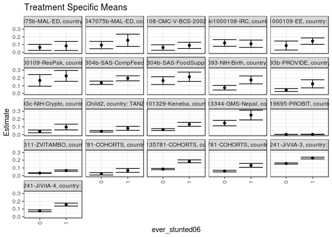

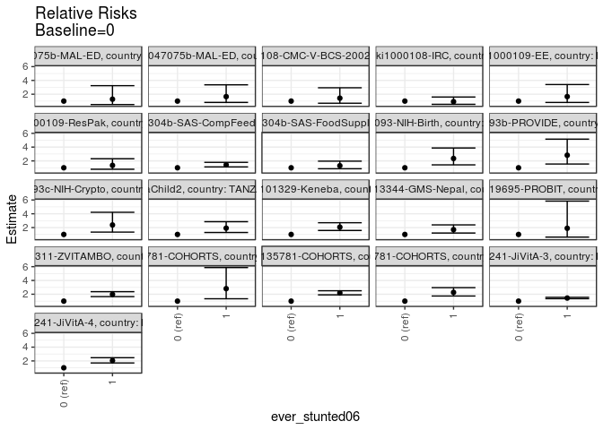

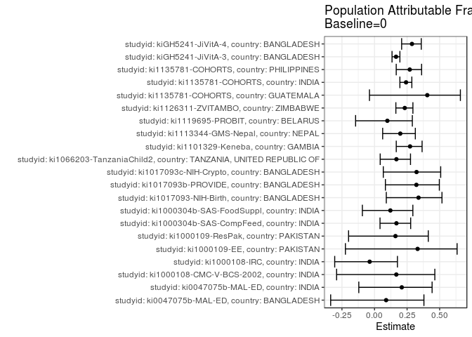

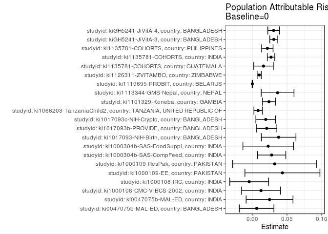

## Results Table

### Parameter: TSM

| studyid | country | intervention_level | baseline_level | estimate | ci_lower | ci_upper |
| --- | --- | --- | --- | --- | --- | --- |
| ki0047075b-MAL-ED | BANGLADESH | 0 | NA | 0.0645161 | 0.0257599 | 0.1032723 |
| ki0047075b-MAL-ED | BANGLADESH | 1 | NA | 0.0823529 | 0.0237900 | 0.1409159 |
| ki0047075b-MAL-ED | INDIA | 0 | NA | 0.0942170 | 0.0471734 | 0.1412606 |
| ki0047075b-MAL-ED | INDIA | 1 | NA | 0.1554809 | 0.0765471 | 0.2344148 |
| ki1000108-CMC-V-BCS-2002 | INDIA | 0 | NA | 0.0630142 | 0.0274496 | 0.0985788 |
| ki1000108-CMC-V-BCS-2002 | INDIA | 1 | NA | 0.0899212 | 0.0496376 | 0.1302049 |
| ki1000108-IRC | INDIA | 0 | NA | 0.1214366 | 0.0786632 | 0.1642100 |
| ki1000108-IRC | INDIA | 1 | NA | 0.1115984 | 0.0645016 | 0.1586952 |
| ki1000109-EE | PAKISTAN | 0 | NA | 0.0879121 | 0.0296544 | 0.1461697 |
| ki1000109-EE | PAKISTAN | 1 | NA | 0.1453901 | 0.1041938 | 0.1865863 |
| ki1000109-ResPak | PAKISTAN | 0 | NA | 0.1685595 | 0.0934922 | 0.2436267 |
| ki1000109-ResPak | PAKISTAN | 1 | NA | 0.2272178 | 0.1573133 | 0.2971222 |
| ki1000304b-SAS-CompFeed | INDIA | 0 | NA | 0.1378455 | 0.1163797 | 0.1593114 |
| ki1000304b-SAS-CompFeed | INDIA | 1 | NA | 0.1955463 | 0.1633241 | 0.2277685 |
| ki1000304b-SAS-FoodSuppl | INDIA | 0 | NA | 0.1660534 | 0.1156244 | 0.2164824 |
| ki1000304b-SAS-FoodSuppl | INDIA | 1 | NA | 0.2155181 | 0.1554435 | 0.2755927 |
| ki1017093-NIH-Birth | BANGLADESH | 0 | NA | 0.0745322 | 0.0444144 | 0.1046500 |
| ki1017093-NIH-Birth | BANGLADESH | 1 | NA | 0.1750665 | 0.1242481 | 0.2258849 |
| ki1017093b-PROVIDE | BANGLADESH | 0 | NA | 0.0441324 | 0.0251381 | 0.0631267 |
| ki1017093b-PROVIDE | BANGLADESH | 1 | NA | 0.1245524 | 0.0721677 | 0.1769372 |
| ki1017093c-NIH-Crypto | BANGLADESH | 0 | NA | 0.0408281 | 0.0233315 | 0.0583248 |
| ki1017093c-NIH-Crypto | BANGLADESH | 1 | NA | 0.0969729 | 0.0599699 | 0.1339759 |
| ki1066203-TanzaniaChild2 | TANZANIA, UNITED REPUBLIC OF | 0 | NA | 0.0420524 | 0.0321257 | 0.0519791 |
| ki1066203-TanzaniaChild2 | TANZANIA, UNITED REPUBLIC OF | 1 | NA | 0.0805178 | 0.0546408 | 0.1063948 |
| ki1101329-Keneba | GAMBIA | 0 | NA | 0.0642131 | 0.0519987 | 0.0764276 |
| ki1101329-Keneba | GAMBIA | 1 | NA | 0.1325034 | 0.1073179 | 0.1576889 |
| ki1113344-GMS-Nepal | NEPAL | 0 | NA | 0.1482261 | 0.1133856 | 0.1830665 |
| ki1113344-GMS-Nepal | NEPAL | 1 | NA | 0.2513342 | 0.1886039 | 0.3140646 |
| ki1119695-PROBIT | BELARUS | 0 | NA | 0.0013038 | 0.0002440 | 0.0023635 |
| ki1119695-PROBIT | BELARUS | 1 | NA | 0.0024728 | 0.0001388 | 0.0048068 |
| ki1126311-ZVITAMBO | ZIMBABWE | 0 | NA | 0.0331995 | 0.0291203 | 0.0372788 |
| ki1126311-ZVITAMBO | ZIMBABWE | 1 | NA | 0.0657921 | 0.0572195 | 0.0743648 |
| ki1135781-COHORTS | GUATEMALA | 0 | NA | 0.0238474 | 0.0086563 | 0.0390384 |
| ki1135781-COHORTS | GUATEMALA | 1 | NA | 0.0670302 | 0.0420635 | 0.0919970 |
| ki1135781-COHORTS | INDIA | 0 | NA | 0.0847828 | 0.0770521 | 0.0925135 |
| ki1135781-COHORTS | INDIA | 1 | NA | 0.1854393 | 0.1667706 | 0.2041080 |
| ki1135781-COHORTS | PHILIPPINES | 0 | NA | 0.0586901 | 0.0479129 | 0.0694674 |
| ki1135781-COHORTS | PHILIPPINES | 1 | NA | 0.1331106 | 0.1077933 | 0.1584280 |
| kiGH5241-JiVitA-3 | BANGLADESH | 0 | NA | 0.1567512 | 0.1487652 | 0.1647372 |
| kiGH5241-JiVitA-3 | BANGLADESH | 1 | NA | 0.2269151 | 0.2157536 | 0.2380766 |
| kiGH5241-JiVitA-4 | BANGLADESH | 0 | NA | 0.0764451 | 0.0650823 | 0.0878080 |
| kiGH5241-JiVitA-4 | BANGLADESH | 1 | NA | 0.1568189 | 0.1376778 | 0.1759600 |

### Parameter: E(Y)

| studyid | country | intervention_level | baseline_level | estimate | ci_lower | ci_upper |
| --- | --- | --- | --- | --- | --- | --- |
| ki0047075b-MAL-ED | BANGLADESH | NA | NA | 0.0708333 | 0.0383085 | 0.1033581 |
| ki0047075b-MAL-ED | INDIA | NA | NA | 0.1191489 | 0.0776405 | 0.1606574 |
| ki1000108-CMC-V-BCS-2002 | INDIA | NA | NA | 0.0756757 | 0.0486905 | 0.1026609 |
| ki1000108-IRC | INDIA | NA | NA | 0.1170732 | 0.0859146 | 0.1482317 |
| ki1000109-EE | PAKISTAN | NA | NA | 0.1313673 | 0.0970401 | 0.1656945 |
| ki1000109-ResPak | PAKISTAN | NA | NA | 0.2008547 | 0.1494120 | 0.2522974 |
| ki1000304b-SAS-CompFeed | INDIA | NA | NA | 0.1657061 | 0.1471754 | 0.1842367 |
| ki1000304b-SAS-FoodSuppl | INDIA | NA | NA | 0.1890547 | 0.1507312 | 0.2273783 |
| ki1017093-NIH-Birth | BANGLADESH | NA | NA | 0.1125461 | 0.0859151 | 0.1391771 |
| ki1017093b-PROVIDE | BANGLADESH | NA | NA | 0.0650407 | 0.0455353 | 0.0845460 |
| ki1017093c-NIH-Crypto | BANGLADESH | NA | NA | 0.0602740 | 0.0429977 | 0.0775502 |
| ki1066203-TanzaniaChild2 | TANZANIA, UNITED REPUBLIC OF | NA | NA | 0.0505451 | 0.0409848 | 0.0601054 |
| ki1101329-Keneba | GAMBIA | NA | NA | 0.0882993 | 0.0766987 | 0.0998998 |
| ki1113344-GMS-Nepal | NEPAL | NA | NA | 0.1847458 | 0.1534039 | 0.2160876 |
| ki1119695-PROBIT | BELARUS | NA | NA | 0.0014462 | 0.0004207 | 0.0024717 |
| ki1126311-ZVITAMBO | ZIMBABWE | NA | NA | 0.0432327 | 0.0393972 | 0.0470683 |
| ki1135781-COHORTS | GUATEMALA | NA | NA | 0.0400782 | 0.0280529 | 0.0521035 |
| ki1135781-COHORTS | INDIA | NA | NA | 0.1118526 | 0.1044114 | 0.1192938 |
| ki1135781-COHORTS | PHILIPPINES | NA | NA | 0.0804557 | 0.0703953 | 0.0905161 |
| kiGH5241-JiVitA-3 | BANGLADESH | NA | NA | 0.1877787 | 0.1812440 | 0.1943134 |
| kiGH5241-JiVitA-4 | BANGLADESH | NA | NA | 0.1072855 | 0.0967458 | 0.1178252 |

### Parameter: RR

| studyid | country | intervention_level | baseline_level | estimate | ci_lower | ci_upper |
| --- | --- | --- | --- | --- | --- | --- |
| ki0047075b-MAL-ED | BANGLADESH | 0 | 0 | 1.0000000 | 1.0000000 | 1.000000 |
| ki0047075b-MAL-ED | BANGLADESH | 1 | 0 | 1.2764706 | 0.5031874 | 3.238112 |
| ki0047075b-MAL-ED | INDIA | 0 | 0 | 1.0000000 | 1.0000000 | 1.000000 |
| ki0047075b-MAL-ED | INDIA | 1 | 0 | 1.6502431 | 0.8092349 | 3.365280 |
| ki1000108-CMC-V-BCS-2002 | INDIA | 0 | 0 | 1.0000000 | 1.0000000 | 1.000000 |
| ki1000108-CMC-V-BCS-2002 | INDIA | 1 | 0 | 1.4270003 | 0.6933879 | 2.936783 |
| ki1000108-IRC | INDIA | 0 | 0 | 1.0000000 | 1.0000000 | 1.000000 |
| ki1000108-IRC | INDIA | 1 | 0 | 0.9189848 | 0.5299692 | 1.593551 |
| ki1000109-EE | PAKISTAN | 0 | 0 | 1.0000000 | 1.0000000 | 1.000000 |
| ki1000109-EE | PAKISTAN | 1 | 0 | 1.6538121 | 0.8044198 | 3.400084 |
| ki1000109-ResPak | PAKISTAN | 0 | 0 | 1.0000000 | 1.0000000 | 1.000000 |
| ki1000109-ResPak | PAKISTAN | 1 | 0 | 1.3479979 | 0.7859875 | 2.311867 |
| ki1000304b-SAS-CompFeed | INDIA | 0 | 0 | 1.0000000 | 1.0000000 | 1.000000 |
| ki1000304b-SAS-CompFeed | INDIA | 1 | 0 | 1.4185903 | 1.1267762 | 1.785979 |
| ki1000304b-SAS-FoodSuppl | INDIA | 0 | 0 | 1.0000000 | 1.0000000 | 1.000000 |
| ki1000304b-SAS-FoodSuppl | INDIA | 1 | 0 | 1.2978840 | 0.8591319 | 1.960704 |
| ki1017093-NIH-Birth | BANGLADESH | 0 | 0 | 1.0000000 | 1.0000000 | 1.000000 |
| ki1017093-NIH-Birth | BANGLADESH | 1 | 0 | 2.3488710 | 1.4254340 | 3.870537 |
| ki1017093b-PROVIDE | BANGLADESH | 0 | 0 | 1.0000000 | 1.0000000 | 1.000000 |
| ki1017093b-PROVIDE | BANGLADESH | 1 | 0 | 2.8222441 | 1.5463083 | 5.151018 |
| ki1017093c-NIH-Crypto | BANGLADESH | 0 | 0 | 1.0000000 | 1.0000000 | 1.000000 |
| ki1017093c-NIH-Crypto | BANGLADESH | 1 | 0 | 2.3751477 | 1.3384148 | 4.214931 |
| ki1066203-TanzaniaChild2 | TANZANIA, UNITED REPUBLIC OF | 0 | 0 | 1.0000000 | 1.0000000 | 1.000000 |
| ki1066203-TanzaniaChild2 | TANZANIA, UNITED REPUBLIC OF | 1 | 0 | 1.9147009 | 1.2848699 | 2.853269 |
| ki1101329-Keneba | GAMBIA | 0 | 0 | 1.0000000 | 1.0000000 | 1.000000 |
| ki1101329-Keneba | GAMBIA | 1 | 0 | 2.0634939 | 1.5775612 | 2.699108 |
| ki1113344-GMS-Nepal | NEPAL | 0 | 0 | 1.0000000 | 1.0000000 | 1.000000 |
| ki1113344-GMS-Nepal | NEPAL | 1 | 0 | 1.6956142 | 1.2047103 | 2.386555 |
| ki1119695-PROBIT | BELARUS | 0 | 0 | 1.0000000 | 1.0000000 | 1.000000 |
| ki1119695-PROBIT | BELARUS | 1 | 0 | 1.8966370 | 0.6161343 | 5.838390 |
| ki1126311-ZVITAMBO | ZIMBABWE | 0 | 0 | 1.0000000 | 1.0000000 | 1.000000 |
| ki1126311-ZVITAMBO | ZIMBABWE | 1 | 0 | 1.9817184 | 1.6571851 | 2.369806 |
| ki1135781-COHORTS | GUATEMALA | 0 | 0 | 1.0000000 | 1.0000000 | 1.000000 |
| ki1135781-COHORTS | GUATEMALA | 1 | 0 | 2.8108004 | 1.3457376 | 5.870832 |
| ki1135781-COHORTS | INDIA | 0 | 0 | 1.0000000 | 1.0000000 | 1.000000 |
| ki1135781-COHORTS | INDIA | 1 | 0 | 2.1872279 | 1.9103305 | 2.504261 |
| ki1135781-COHORTS | PHILIPPINES | 0 | 0 | 1.0000000 | 1.0000000 | 1.000000 |
| ki1135781-COHORTS | PHILIPPINES | 1 | 0 | 2.2680236 | 1.7419432 | 2.952984 |
| kiGH5241-JiVitA-3 | BANGLADESH | 0 | 0 | 1.0000000 | 1.0000000 | 1.000000 |
| kiGH5241-JiVitA-3 | BANGLADESH | 1 | 0 | 1.4476131 | 1.3520335 | 1.549950 |
| kiGH5241-JiVitA-4 | BANGLADESH | 0 | 0 | 1.0000000 | 1.0000000 | 1.000000 |
| kiGH5241-JiVitA-4 | BANGLADESH | 1 | 0 | 2.0513913 | 1.7056354 | 2.467237 |

### Parameter: PAR

| studyid | country | intervention_level | baseline_level | estimate | ci_lower | ci_upper |
| --- | --- | --- | --- | --- | --- | --- |
| ki0047075b-MAL-ED | BANGLADESH | 0 | NA | 0.0063172 | -0.0185779 | 0.0312123 |
| ki0047075b-MAL-ED | INDIA | 0 | NA | 0.0249319 | -0.0088288 | 0.0586927 |
| ki1000108-CMC-V-BCS-2002 | INDIA | 0 | NA | 0.0126615 | -0.0153545 | 0.0406775 |
| ki1000108-IRC | INDIA | 0 | NA | -0.0043634 | -0.0323307 | 0.0236039 |
| ki1000109-EE | PAKISTAN | 0 | NA | 0.0434552 | -0.0105474 | 0.0974578 |
| ki1000109-ResPak | PAKISTAN | 0 | NA | 0.0322952 | -0.0281951 | 0.0927855 |
| ki1000304b-SAS-CompFeed | INDIA | 0 | NA | 0.0278605 | 0.0074054 | 0.0483156 |
| ki1000304b-SAS-FoodSuppl | INDIA | 0 | NA | 0.0230013 | -0.0134632 | 0.0594658 |
| ki1017093-NIH-Birth | BANGLADESH | 0 | NA | 0.0380139 | 0.0130776 | 0.0629503 |
| ki1017093b-PROVIDE | BANGLADESH | 0 | NA | 0.0209082 | 0.0063913 | 0.0354252 |
| ki1017093c-NIH-Crypto | BANGLADESH | 0 | NA | 0.0194458 | 0.0052256 | 0.0336660 |
| ki1066203-TanzaniaChild2 | TANZANIA, UNITED REPUBLIC OF | 0 | NA | 0.0084927 | 0.0024330 | 0.0145523 |
| ki1101329-Keneba | GAMBIA | 0 | NA | 0.0240861 | 0.0148413 | 0.0333310 |
| ki1113344-GMS-Nepal | NEPAL | 0 | NA | 0.0365197 | 0.0128851 | 0.0601542 |
| ki1119695-PROBIT | BELARUS | 0 | NA | 0.0001424 | -0.0001556 | 0.0004405 |
| ki1126311-ZVITAMBO | ZIMBABWE | 0 | NA | 0.0100332 | 0.0070707 | 0.0129957 |
| ki1135781-COHORTS | GUATEMALA | 0 | NA | 0.0162308 | 0.0021519 | 0.0303097 |
| ki1135781-COHORTS | INDIA | 0 | NA | 0.0270698 | 0.0216867 | 0.0324529 |
| ki1135781-COHORTS | PHILIPPINES | 0 | NA | 0.0217655 | 0.0135198 | 0.0300113 |
| kiGH5241-JiVitA-3 | BANGLADESH | 0 | NA | 0.0310275 | 0.0252961 | 0.0367590 |
| kiGH5241-JiVitA-4 | BANGLADESH | 0 | NA | 0.0308404 | 0.0224032 | 0.0392776 |

### Parameter: PAF

| studyid | country | intervention_level | baseline_level | estimate | ci_lower | ci_upper |
| --- | --- | --- | --- | --- | --- | --- |
| ki0047075b-MAL-ED | BANGLADESH | 0 | NA | 0.0891841 | -0.3366919 | 0.3793741 |
| ki0047075b-MAL-ED | INDIA | 0 | NA | 0.2092502 | -0.1206589 | 0.4420379 |
| ki1000108-CMC-V-BCS-2002 | INDIA | 0 | NA | 0.1673127 | -0.2910685 | 0.4629501 |
| ki1000108-IRC | INDIA | 0 | NA | -0.0372710 | -0.3056166 | 0.1759210 |
| ki1000109-EE | PAKISTAN | 0 | NA | 0.3307917 | -0.2234703 | 0.6339594 |
| ki1000109-ResPak | PAKISTAN | 0 | NA | 0.1607891 | -0.1991792 | 0.4127025 |
| ki1000304b-SAS-CompFeed | INDIA | 0 | NA | 0.1681321 | 0.0422130 | 0.2774968 |
| ki1000304b-SAS-FoodSuppl | INDIA | 0 | NA | 0.1216648 | -0.0931873 | 0.2942904 |
| ki1017093-NIH-Birth | BANGLADESH | 0 | NA | 0.3377631 | 0.0904077 | 0.5178524 |
| ki1017093b-PROVIDE | BANGLADESH | 0 | NA | 0.3214642 | 0.0835258 | 0.4976281 |
| ki1017093c-NIH-Crypto | BANGLADESH | 0 | NA | 0.3226239 | 0.0673249 | 0.5080405 |
| ki1066203-TanzaniaChild2 | TANZANIA, UNITED REPUBLIC OF | 0 | NA | 0.1680217 | 0.0436381 | 0.2762280 |
| ki1101329-Keneba | GAMBIA | 0 | NA | 0.2727783 | 0.1669168 | 0.3651878 |
| ki1113344-GMS-Nepal | NEPAL | 0 | NA | 0.1976753 | 0.0625448 | 0.3133273 |
| ki1119695-PROBIT | BELARUS | 0 | NA | 0.0984898 | -0.1451996 | 0.2903240 |
| ki1126311-ZVITAMBO | ZIMBABWE | 0 | NA | 0.2320739 | 0.1638743 | 0.2947108 |
| ki1135781-COHORTS | GUATEMALA | 0 | NA | 0.4049786 | -0.0387544 | 0.6591587 |
| ki1135781-COHORTS | INDIA | 0 | NA | 0.2420133 | 0.1947756 | 0.2864798 |
| ki1135781-COHORTS | PHILIPPINES | 0 | NA | 0.2705282 | 0.1666547 | 0.3614542 |
| kiGH5241-JiVitA-3 | BANGLADESH | 0 | NA | 0.1652346 | 0.1345255 | 0.1948541 |
| kiGH5241-JiVitA-4 | BANGLADESH | 0 | NA | 0.2874608 | 0.2081524 | 0.3588259 |